# Data Rangers - Crime in NE

Each county represented falls in the top 20% of counties in NE by population, we can conclude that if you live in an area with a population greater than 20,000, you will experience a higher crime rate than rural areas. It is not true however - the higher the population the higher the crime, there is just a threshold where counties will begin to become urbanized.

```r
# Sort by crime rate per 1000
lawCrimeSortCrimeRate <- lawCrime[order(-lawCrime$crime_per_1000),]
lawCrimeSortCrimeRate <- head(lawCrimeSortCrimeRate, 30)
worstCrimeRatesDep <- table(lawCrimeSortCrimeRate$department)
worstCrimeRatesCounty <- table(lawCrimeSortCrimeRate$county)

worstCrimeRatesDep
```

```
##
##     Beatrice PD Grand Island PD     Hastings PD    Lexington PD
##               1               7               1               1
##      Lincoln PD North Platte PD        Omaha PD  Scottsbluff PD
##               1               8               4               7
```

```r
worstCrimeRatesCounty
```

```
##
##        Adams       Dawson      Douglas         Gage         Hall
##            1            1            4            1            7
##    Lancaster      Lincoln Scotts Bluff
##            1            8            7
```

**Plotting the 2 variables which show some positive correlation with the crime rate per 1000**  
My analysis of these plots is that it is largely the urban areas which account for the positive correlation. Our conclusion is that at least in Nebraska, your relative crime rate will increase as you move to more populous areas of the state.

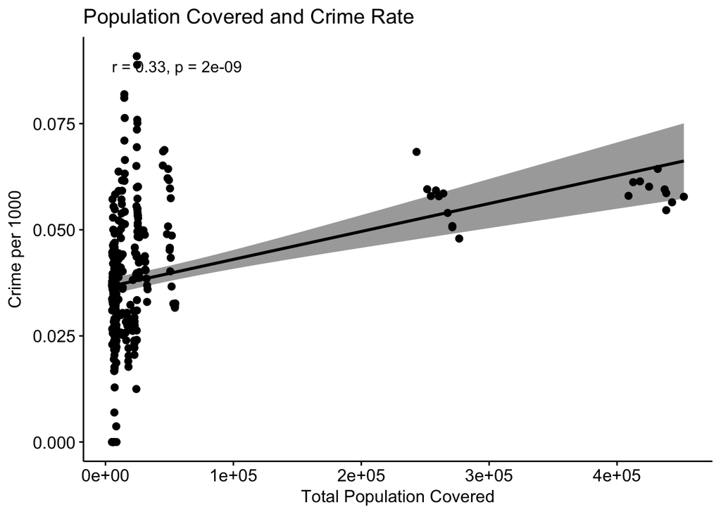

```r
library("ggpubr")
ggscatter(lawCrime, x = "pop_covered", y = "crime_per_1000",
          add = "reg.line", conf.int = TRUE,
          cor.coef = TRUE, cor.method = "pearson",
          xlab = "Total Population Covered", ylab = "Crime per 1000", main = "Population Covered and Crime Rate")
```

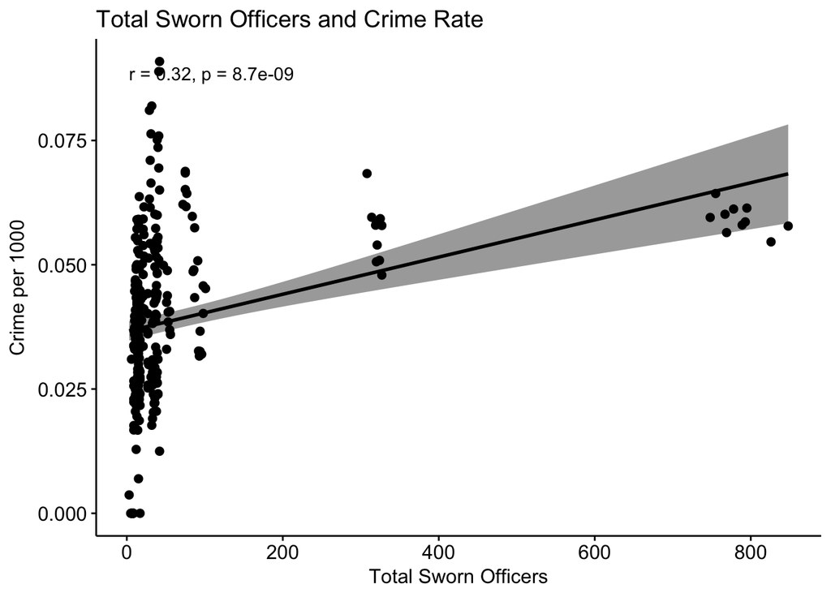

```r
ggscatter(lawCrime, x = "total_so", y = "crime_per_1000",
          add = "reg.line", conf.int = TRUE,
          cor.coef = TRUE, cor.method = "pearson",
          xlab = "Total Sworn Officers", ylab = "Crime per 1000", main = "Total Sworn Officers and Crime Rate")
```

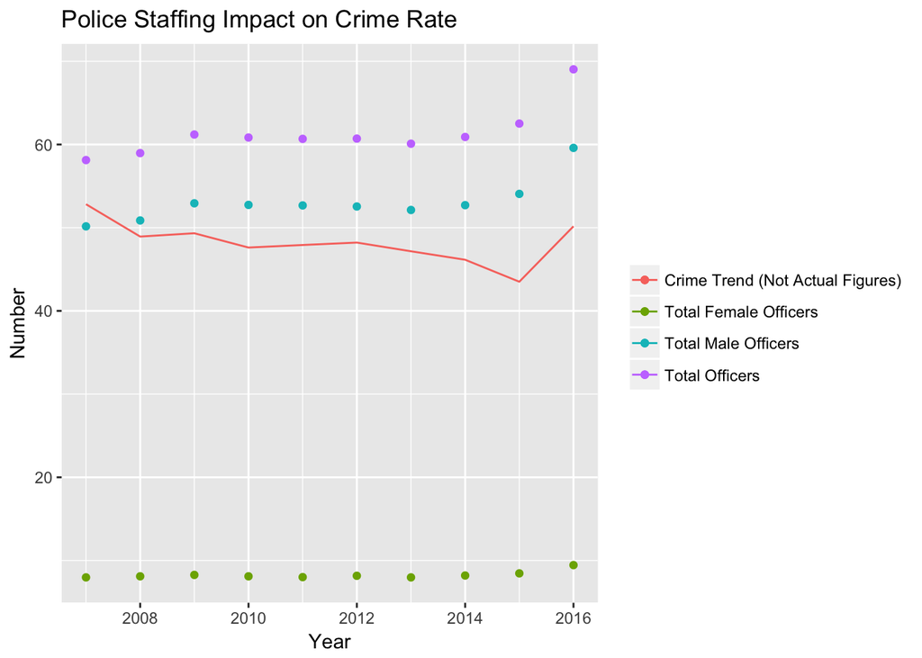

```r
library(ggplot2)

p <- ggplot(hiringCrimePlot, aes(x=years, y=cAvg)) +
  geom_point(aes(x = years, y = totAvg, color = "Total Officers")) +
  geom_point(aes(x = years, y = fAvg, color = "Total Female Officers")) +
  geom_point(aes(x = years, y = mAvg, color = "Total Male Officers")) +
  geom_line(aes(x = years, y = cAvg, color = "Crime Trend (Not Actual Figures)"))
p <- p + scale_fill_discrete(name = "New Legend Title")
p <- p + labs(x = "Year", y = "Number", title = "Police Staffing Impact on Crime Rate")
p <- p + theme(legend.title=element_blank())
p
```

When we compare average hiring data year over year, it isn’t obvious there is any relationship between the hiring rates of officers and the overall incidents of crime across the state. In fact the year with the lowest crime incidence rate (2015), led to the greatest hiring spike, indicating at time this can even be an inverse relationship.

### Looking at the data geographically

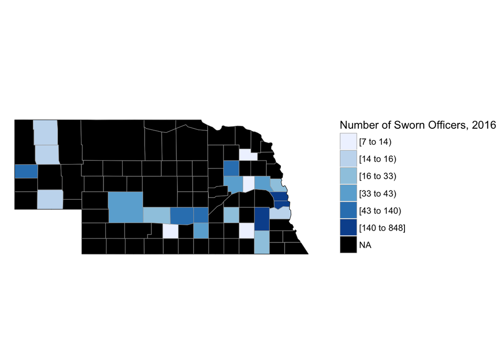

We can see that the actual number of sworn officers differs by regions of the state. Also, most counties do not have a police department located within their borders. Our data doesn’t indicate how police resources are allocated across county lines.

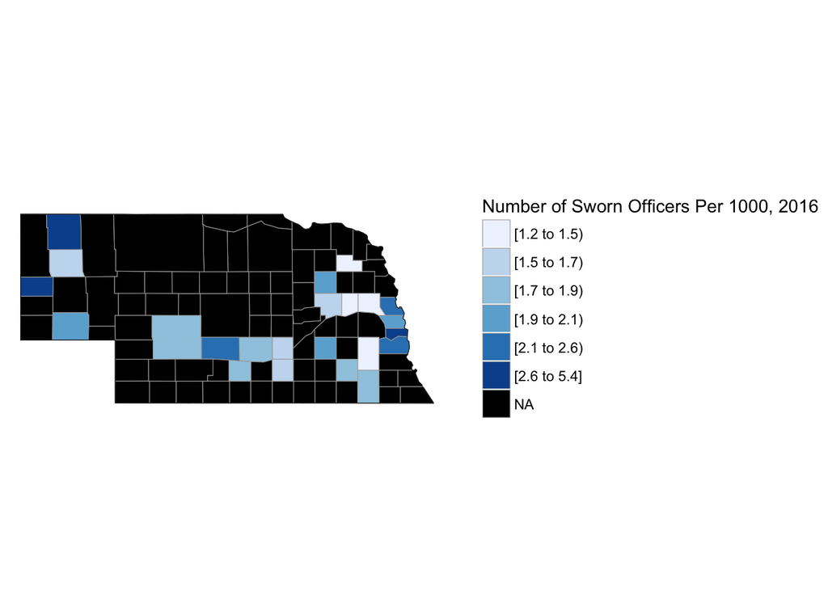